# Chapter 6: Analysis of longitudinal data

```r
date()
```

```
## [1] "Fri Dec  9 01:03:18 2022"
```

*Part 1 of this exercise analyzes RATS data, while Part 2 of this exercise analyzes BPRS data. The goal of this exercise is to use statistical techniques appropriate for longitudinal data analysis to analyze the datasets.All exercises of this week are based on the Chapters 8 and 9 of Vehkalahti and Everitt (2019), included in the special edition MABS4IODS (Part VI).*

**About BPRS Data** *In the BPRS data, in which 40 male subjects were randomly assigned to one of two treatment groups and each subject was rated on the brief psychiatric rating scale (BPRS) measured before treatment began (week 0) and then at weekly intervals for eight weeks. The BPRS assesses the level of 18 symptom constructs such as hostility, suspiciousness, hallucinations and grandiosity; each of these is rated from one (not present) to seven (extremely severe). The scale is used to evaluate patients suspected of having schizophrenia.*

**About RATS Data** *It contains data from a nutrition study conducted in three groups of rats. The groups were put on different diets, and each animal’s body weight (grams) was recorded repeatedly (approximately) weekly, except in week seven when two recordings were taken) over a 9-week period. The question of most interest is whether the growth profiles of the three groups differ.*

## Part 1: Implement the analyses of Chapter 8 of MABS- RATS data

#### Reading Data

```r
#Applying Packages
library(tidyverse)
```

```r
library(ggplot2)
library(readr)
library(dplyr)
library(tidyr)
library(lme4)
#Loading data
RATS <- read.table("https://raw.githubusercontent.com/KimmoVehkalahti/MABS/master/Examples/data/rats.txt", header = TRUE, sep  ='\t')

# Convert the categorical variables of data set to factors
RATS$ID <- factor(RATS$ID)
RATS$Group <- factor(RATS$Group)

glimpse(RATS)
```

```
## Rows: 16
## Columns: 13
## $ ID    <fct> 1, 2, 3, 4, 5, 6, 7, 8, 9, 10, 11, 12, 13, 14, 15, 16
## $ Group <fct> 1, 1, 1, 1, 1, 1, 1, 1, 2, 2, 2, 2, 3, 3, 3, 3
## $ WD1   <int> 240, 225, 245, 260, 255, 260, 275, 245, 410, 405, 445, 555, 470,…
## $ WD8   <int> 250, 230, 250, 255, 260, 265, 275, 255, 415, 420, 445, 560, 465,…
## $ WD15  <int> 255, 230, 250, 255, 255, 270, 260, 260, 425, 430, 450, 565, 475,…
## $ WD22  <int> 260, 232, 255, 265, 270, 275, 270, 268, 428, 440, 452, 580, 485,…
## $ WD29  <int> 262, 240, 262, 265, 270, 275, 273, 270, 438, 448, 455, 590, 487,…
## $ WD36  <int> 258, 240, 265, 268, 273, 277, 274, 265, 443, 460, 455, 597, 493,…
## $ WD43  <int> 266, 243, 267, 270, 274, 278, 276, 265, 442, 458, 451, 595, 493,…
## $ WD44  <int> 266, 244, 267, 272, 273, 278, 271, 267, 446, 464, 450, 595, 504,…
## $ WD50  <int> 265, 238, 264, 274, 276, 284, 282, 273, 456, 475, 462, 612, 507,…
## $ WD57  <int> 272, 247, 268, 273, 278, 279, 281, 274, 468, 484, 466, 618, 518,…
## $ WD64  <int> 278, 245, 269, 275, 280, 281, 284, 278, 478, 496, 472, 628, 525,…
```

```r
# Convert to long form
RATSL <- RATS %>%
  gather(key = WD, value = Weight, -ID, -Group) %>%
  mutate(Time = as.integer(substr(WD,3,4)))

glimpse(RATSL)
```

```
## Rows: 176
## Columns: 5
## $ ID     <fct> 1, 2, 3, 4, 5, 6, 7, 8, 9, 10, 11, 12, 13, 14, 15, 16, 1, 2, 3,…
## $ Group  <fct> 1, 1, 1, 1, 1, 1, 1, 1, 2, 2, 2, 2, 3, 3, 3, 3, 1, 1, 1, 1, 1, …
## $ WD     <chr> "WD1", "WD1", "WD1", "WD1", "WD1", "WD1", "WD1", "WD1", "WD1", …
## $ Weight <int> 240, 225, 245, 260, 255, 260, 275, 245, 410, 405, 445, 555, 470…
## $ Time   <int> 1, 1, 1, 1, 1, 1, 1, 1, 1, 1, 1, 1, 1, 1, 1, 1, 8, 8, 8, 8, 8, …
```

#### Visualizing RATSL Dataset

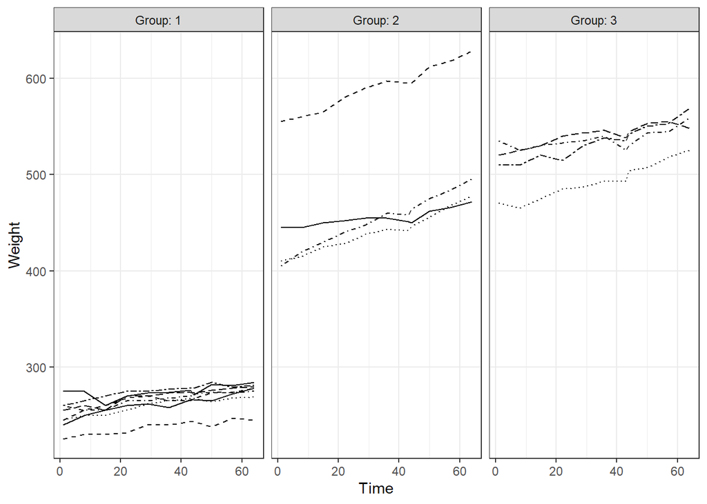

```r
ggplot(RATSL, aes(x = Time, y = Weight, linetype = ID))+
  geom_line() + scale_linetype_manual(values = rep(1:10, times=4))+
  facet_grid(. ~ Group, labeller = label_both)+
  theme_bw() + theme(legend.position = "none")+
  theme(panel.grid.minor.y = element_blank()) +
  scale_y_continuous(limits = c(min(RATSL$Weight), max(RATSL$Weight)))
```

#### Standardising the variable weight

```r
RATSL <- RATSL %>%
  group_by(Time) %>%
  mutate(stdweight = Weight) %>%
  ungroup()

# Glimpse the data
glimpse(RATSL)
```

```
## Rows: 176
## Columns: 6
## $ ID        <fct> 1, 2, 3, 4, 5, 6, 7, 8, 9, 10, 11, 12, 13, 14, 15, 16, 1, 2,…
## $ Group     <fct> 1, 1, 1, 1, 1, 1, 1, 1, 2, 2, 2, 2, 3, 3, 3, 3, 1, 1, 1, 1, …
## $ WD        <chr> "WD1", "WD1", "WD1", "WD1", "WD1", "WD1", "WD1", "WD1", "WD1…
## $ Weight    <int> 240, 225, 245, 260, 255, 260, 275, 245, 410, 405, 445, 555, …
## $ Time      <int> 1, 1, 1, 1, 1, 1, 1, 1, 1, 1, 1, 1, 1, 1, 1, 1, 8, 8, 8, 8, …
## $ stdweight <int> 240, 225, 245, 260, 255, 260, 275, 245, 410, 405, 445, 555, …
```

#### Visualizing standardized RATSL

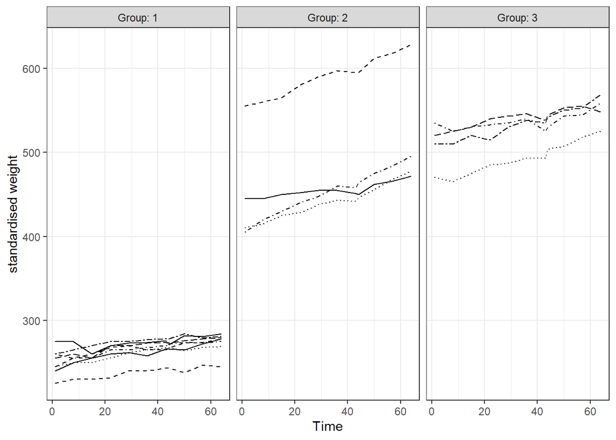

```r
#Plot again with the standardised RATSL

ggplot(RATSL, aes(x = Time, y = stdweight, linetype = ID)) +
  geom_line() + scale_linetype_manual(values = rep(1:10, times=4))+
  facet_grid(. ~ Group, labeller = label_both)+
  theme_bw() + theme(legend.position = "none")+
  theme(panel.grid.minor.y = element_blank())+
  scale_y_continuous(name = "standardised weight")
```

*As we can see there is no change between values of weight and standard weight, we will create average mean and standard deviation profile of the groups to see if there it provides a better understanding*

#### Creating average mean and standard Deviation profile of groups

```r
# Number of weeks, baseline (week 0) included
n <- RATSL$Time %>% unique() %>% length()

RATSS <- RATSL %>%
  group_by(Group, Time) %>%
  summarise(mean = mean(Weight), sd = sd(Weight)) %>%
  ungroup()
# Glimpse the data
glimpse(RATSS)
```

```
## Rows: 33
## Columns: 4
## $ Group <fct> 1, 1, 1, 1, 1, 1, 1, 1, 1, 1, 1, 2, 2, 2, 2, 2, 2, 2, 2, 2, 2, 2…
## $ Time  <int> 1, 8, 15, 22, 29, 36, 43, 44, 50, 57, 64, 1, 8, 15, 22, 29, 36, …
## $ mean  <dbl> 250.625, 255.000, 254.375, 261.875, 264.625, 265.000, 267.375, 2…
## $ sd    <dbl> 15.22158, 13.09307, 11.47591, 13.60081, 11.05748, 11.78377, 10.9…
```

**Observation** *The new RATSS data set has 33 rows and 4 colums in which Group is a factor, Time is integer and Mean and sd are in double precision floating point format*

#### Visualizing the new mean growth profile for three groups of RATS

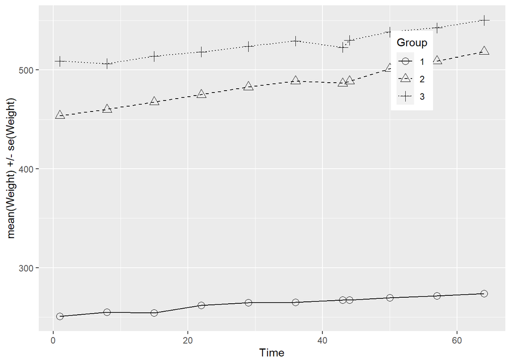

```r
ggplot(RATSS, aes(x = Time, y = mean, linetype = Group, shape = Group)) +
  geom_line() +
  scale_linetype_manual(values = c(1,2,3)) +
  geom_point(size=3) +
  scale_shape_manual(values = c(1,2,3)) +
  #geom_errorbar(aes(ymin=mean-se, ymax=mean+se, linetype="1"), width=0.3) +
  theme(legend.position = c(0.8,0.8)) +
  scale_y_continuous(name = "mean(Weight) +/- se(Weight)")
```

**Interpretation** *According to the above Mean weight value ggplot, all the three groups ar highly distinct from each other. The plot has made this more clear especially for Group 2 and Group 3 which seemingly had some similar plottings for certain values in the previous graphs*

## Part 2: Implement the analyses of Chapter 9 of MABS- BPRS data